# GLM Part1

Murray Logan

17 May, 2022

# Preparations

Load the necessary libraries

```r
library(car) # for regression diagnostics
library(broom) # for tidy output
library(ggfortify) # for model diagnostics
library(DHARMa) # for residual diagnostics
library(performance) # for residuals diagnostics
library(see) # for plotting residuals
library(sjPlot) # for outputs
library(knitr) # for kable
library(effects) # for partial effects plots
library(ggeffects) # for partial effects plots
library(emmeans) # for estimating marginal means
library(modelr) # for auxillary modelling functions
library(tidyverse) # for data wrangling
library(lindia) # for diagnostics of lm and glm
```

# Scenario

Here is an example from Fowler, Cohen, and Jarvis (1998). An agriculturalist was interested in the effects of fertiliser load on the yield of grass. Grass seed was sown uniformly over an area and different quantities of commercial fertiliser were applied to each of ten 1 m<sup>2</sup> randomly located plots. Two months later the grass from each plot was harvested, dried and weighed. The data are in the file **fertilizer.csv** in the **data** folder.

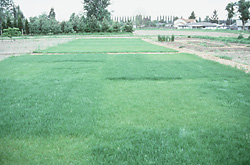

| FERTILIZER | YIELD |
| --- | --- |
| 25 | 84 |
| 50 | 80 |
| 75 | 90 |
| 100 | 154 |
| 125 | 148 |
| ... | ... |

| **FERTILIZER**: | Mass of fertiliser (g.m<sup>-2</sup>) - Predictor variable |
| --- | --- |
| **YIELD**: | Yield of grass (g.m<sup>-2</sup>) - Response variable |

The aim of the analysis is to investigate the relationship between fertiliser concentration and grass yield.

# Read in the data

We will start off by reading in the Fertiliser data. There are many functions in R that can read in a CSV file. We will use a the `read_csv()` function as it is part of the tidyverse ecosystem.

```r
fert <- read_csv("../public/data/fertilizer.csv", trim_ws = TRUE)
```

After reading in a dataset, it is always a good idea to quickly explore a few summaries in order to ascertain whether the imported data are correctly transcribed. In particular, we should pay attention to whether there are any unexpected missing values and ensure that each variable (column) has the expected class (e.g. that variables we expected to be considered numbers are indeed listed as either `<dbl>` or `<int>` and not `<char>`).

```r
glimpse(fert)
```

```
## Rows: 10
## Columns: 2
## $ FERTILIZER <dbl> 25, 50, 75, 100, 125, 150, 175, 200, 225, 250
## $ YIELD      <dbl> 84, 80, 90, 154, 148, 169, 206, 244, 212, 248
```

```r
## Explore the first 6 rows of the data
head(fert)
```

| FERTILIZER | YIELD |
| --- | --- |
| 25 | 84 |
| 50 | 80 |
| 75 | 90 |
| 100 | 154 |
| 125 | 148 |
| 150 | 169 |

```r
str(fert)
```

```
## spec_tbl_df [10 × 2] (S3: spec_tbl_df/tbl_df/tbl/data.frame)
##  $ FERTILIZER: num [1:10] 25 50 75 100 125 150 175 200 225 250
##  $ YIELD     : num [1:10] 84 80 90 154 148 169 206 244 212 248
##  - attr(*, "spec")=
##   .. cols(
##   ..   FERTILIZER = col_double(),
##   ..   YIELD = col_double()
##   .. )
##  - attr(*, "problems")=<externalptr>
```

# Exploratory data analysis

The individual responses ($y_i$, observed yields) are each expected to have been **independently** drawn from normal (**Gaussian**) distributions ($\mathcal{N}$). These distributions represent all the possible yields we could have obtained at the specific ($i^th$) level of Fertiliser. Hence the $i^th$ yield observation is expected to have been drawn from a normal distribution with a mean of $\mu_i$.

Although each distribution is expected to come from populations that differ in their means, we assume that all of these distributions have the **same variance** ($\sigma^2$).

Model formula:
$$y_i \sim{} \mathcal{N}(\mu_i, \sigma^2)\\
\mu_i = \beta_0 + \beta_1 x_i$$

where $y_i$ represents the $i$ observed values, $\beta_0$ and $\beta_1$ represent the intercept and slope respectively, and $\sigma^2$ represents the estimated variance.

We intend to explore the relationship between Yield and Fertiliser using simple linear regression. Such an analysis assumes:

- **Normality**: each population is assumed to be normally distributed. This can be initially assessed by exploring the distribution of the response via either boxplots, violin plots or histograms (depending on sample size).
- **Homogeneity of variance**: each population is assumed to be equally varied. This can be initially assessed by exploring the distribution of observed values around an imaginary line of best fit through the cloud of data formed by a scatterplot of Yield against Fertiliser. If the spread of points increases (or decreases) along the trend line, it is likely that the populations are not equally varied.
- **Linearity**: in fitting a straight line through the cloud of data, we are assuming that a linear trend is appropriate. If the trend is not linear, then the inferred relationship may be miss-representative of the true relationship. In addition to an imaginary line, we could fit either a loess or linear smoother through the cloud to help us assess the likelihood of non-linearity.
- **Independence**: to help ensure that the estimates are unbiased, we must assume that all observations are independent. In this case, we assume that the observations were collected from a randomised design in which the level of Fertiliser was applied randomly to the different patches of the field. If however, the researchers had simply moved along the field applying progressively higher Fertiliser concentrations, then there is a chance that they have introduced additional biases or confounding factors. Similarly, if the Fertiliser levels were applied in increasing doses over time, there might also be biases. In the absence of any spatial or temporal information associated with the collection of data, we cannot directly assess this assumption.

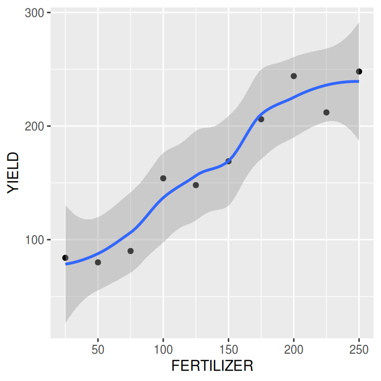

```r
ggplot(fert, aes(y = YIELD, x = FERTILIZER)) +
  geom_point() +
  geom_smooth()
```

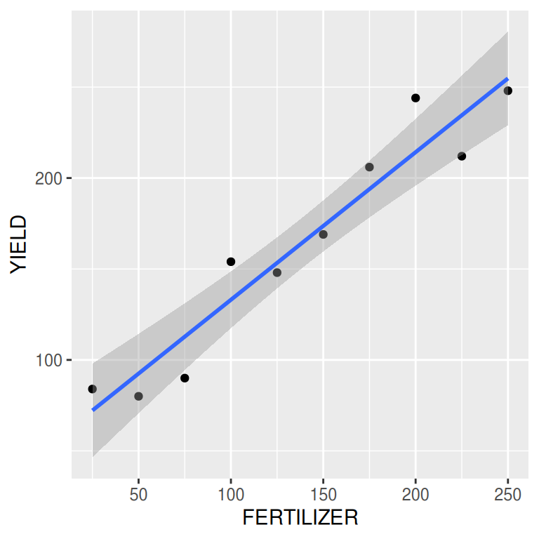

```r
ggplot(fert, aes(y = YIELD, x = FERTILIZER)) +
  geom_point() +
  geom_smooth(method = "lm")
```

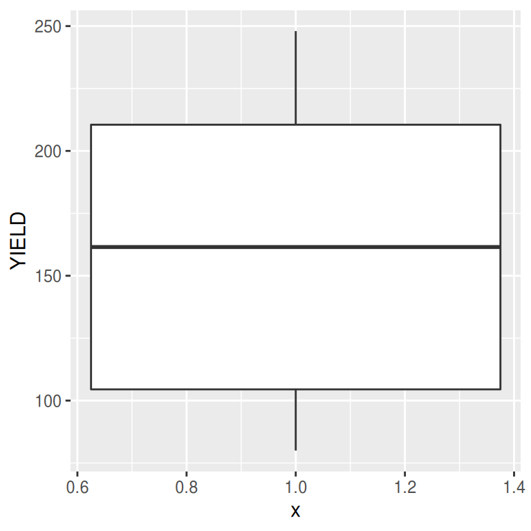

```r
ggplot(fert, aes(y = YIELD)) +
  geom_boxplot(aes(x = 1))
```

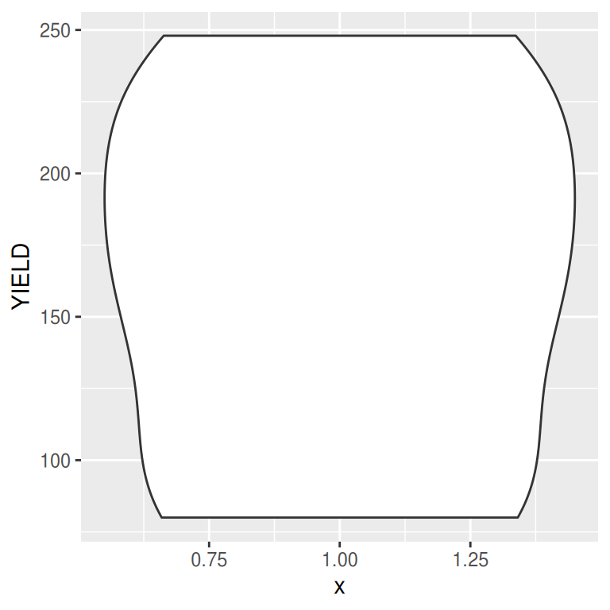

```r
ggplot(fert, aes(y = YIELD)) +
  geom_violin(aes(x = 1))
```

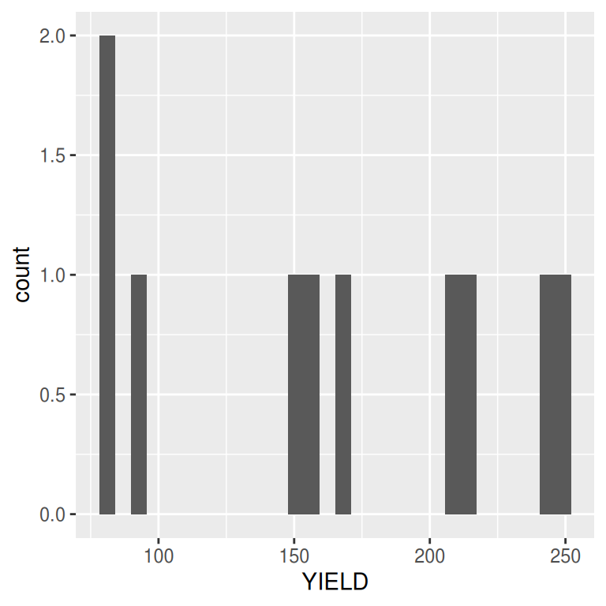

```r
ggplot(fert, aes(x = YIELD)) +
  geom_histogram()
```

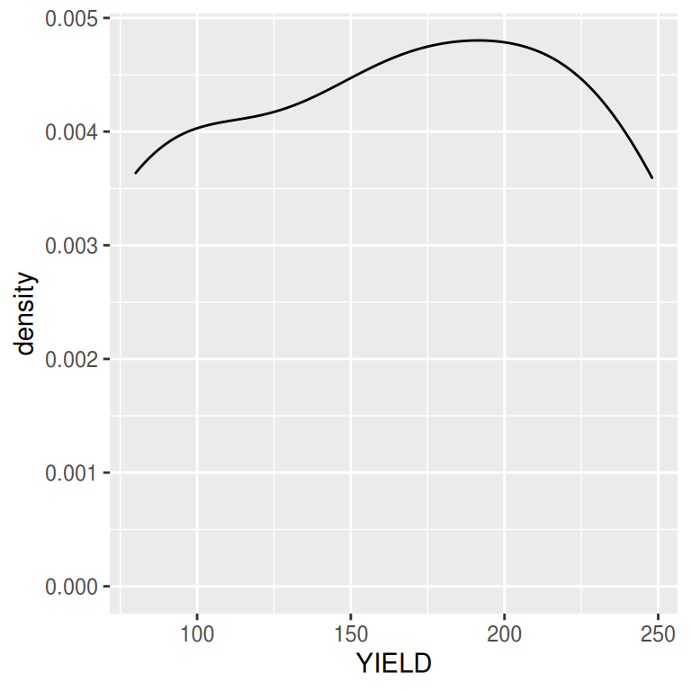

```r
ggplot(fert, aes(x = YIELD)) +
  geom_density()
```

**Conclusions**:

- there is no evidence of non-normality, non-homogeneity of variance or non-linearity
- we have no initial reason to suspect that the assumptions will not be satisfied and thus it is reasonable to assume that the results will be reliable.

# Fit the model

Lets start by performing Ordinary Least Squares (OLS) regression by first principles.

To do so, we expresses the response as a vector ($Y$), the deterministic (linear predictor) as a matrix ($\boldsymbol{X}$) comprising of a column of 1’s (for multiplying the intercept parameter) and the predictor variable (for multiplying the slope parameter). We then also have a vector of beta parameters ($\beta_0$ and $\beta$ representing the intercept and slope respectively).

$$y_i = \beta_0\times 1 + \beta_1\times x_i$$

$$\underbrace{\begin{bmatrix}
y_1\\
y_2\\
y_3\\
...\\
y_i
\end{bmatrix}}_{Y} =
\underbrace{\begin{bmatrix}
1&x_1\\
1&x_2\\
1&x_3\\
...\\
1&x_i
\end{bmatrix}}_{\boldsymbol{X}}
\underbrace{\vphantom{\begin{bmatrix}
y_1\\
y_2\\
y_3\\
...\\
y_i
\end{bmatrix}}\begin{bmatrix}
\beta_0&\beta
\end{bmatrix}}_{\boldsymbol{\beta}}$$

In OLS we estimate the parameters ($\beta_0$ and $\beta$) by minimising the sum of the squared residuals ($\boldsymbol{\varepsilon}$).

$$\begin{align}
Y =& \boldsymbol{X}\boldsymbol{\beta} + \boldsymbol{\varepsilon}\\
\boldsymbol{\varepsilon} =& Y - \boldsymbol{X}\boldsymbol{\beta}
\end{align}$$

We can then minimise the sum of squares residuals. This is essentially $\boldsymbol{\varepsilon}^T\boldsymbol{\varepsilon}$, where $\boldsymbol{\varepsilon}$ is $\boldsymbol{\varepsilon}$ transposed.

$$\small
\begin{bmatrix}
\varepsilon_1&\varepsilon_2&\varepsilon_3&...&\varepsilon_n
\end{bmatrix}
\begin{bmatrix}
\varepsilon_1\\
\varepsilon_2\\
\varepsilon_3\\
...\\
\varepsilon_n\\
\end{bmatrix} =
\begin{bmatrix}
\varepsilon_1\times\varepsilon_1 + \varepsilon_2\times\varepsilon_2 + \varepsilon_3\times\varepsilon_3 + ... + \varepsilon_n\times\varepsilon_n
\end{bmatrix}$$

$$\begin{align}
\boldsymbol{\varepsilon}^T\boldsymbol{\varepsilon} =& (Y - \boldsymbol{X}\boldsymbol{\beta})^T(Y - \boldsymbol{X}\boldsymbol{\beta})\\
\boldsymbol{\beta} =& (\boldsymbol{X}^T\boldsymbol{X})^{-1} \boldsymbol{X}^T Y
\end{align}$$

```r
## Generate the model matrix
X <- model.matrix(~FERTILIZER, data = fert)
## Solve for beta
beta <- solve(t(X) %*% X) %*% t(X) %*% fert$YIELD
beta
```

```
##                   [,1]
## (Intercept) 51.9333333
## FERTILIZER   0.8113939
```

The above simple linear regression model can be fit using the `lm()` function. This function, uses Ordinary Least Squares (OLS). The full model formula would include a 1 (for the intercept) and the predictor values (for the slope). In R, models generally always include an intercept by default and thus we can abbreviate the formula a little by omitting the 1.

```r
fert.lm <- lm(YIELD ~ 1 + FERTILIZER, data = fert)
fert.lm <- lm(YIELD ~ FERTILIZER, data = fert)
```

The `lm()` function returns a list comprising the estimated coefficients, the residuals, the data used to fit the model and various other attributes associated with the model fitting procedure.

```r
## Get the name of the attributes within the lm model
attributes(fert.lm)
```

```
## $names
##  [1] "coefficients"  "residuals"     "effects"       "rank"
##  [5] "fitted.values" "assign"        "qr"            "df.residual"
##  [9] "xlevels"       "call"          "terms"         "model"
##
## $class
## [1] "lm"
```

```r
## Explore all the conttents of the fitted model
str(fert.lm)
```

```
## List of 12
##  $ coefficients : Named num [1:2] 51.933 0.811
##   ..- attr(*, "names")= chr [1:2] "(Intercept)" "FERTILIZER"
##  $ residuals    : Named num [1:10] 11.78 -12.5 -22.79 20.93 -5.36 ...
##   ..- attr(*, "names")= chr [1:10] "1" "2" "3" "4" ...
##  $ effects      : Named num [1:10] -517.03 184.25 -23.73 18.66 -8.96 ...
##   ..- attr(*, "names")= chr [1:10] "(Intercept)" "FERTILIZER" "" "" ...
##  $ rank         : int 2
##  $ fitted.values: Named num [1:10] 72.2 92.5 112.8 133.1 153.4 ...
##   ..- attr(*, "names")= chr [1:10] "1" "2" "3" "4" ...
##  $ assign       : int [1:2] 0 1
##  $ qr           :List of 5
##   ..$ qr   : num [1:10, 1:2] -3.162 0.316 0.316 0.316 0.316 ...
##   .. ..- attr(*, "dimnames")=List of 2
##   .. .. ..$ : chr [1:10] "1" "2" "3" "4" ...
##   .. .. ..$ : chr [1:2] "(Intercept)" "FERTILIZER"
##   .. ..- attr(*, "assign")= int [1:2] 0 1
##   ..$ qraux: num [1:2] 1.32 1.27
##   ..$ pivot: int [1:2] 1 2
##   ..$ tol  : num 1e-07
##   ..$ rank : int 2
##   ..- attr(*, "class")= chr "qr"
##  $ df.residual  : int 8
##  $ xlevels      : Named list()
##  $ call         : language lm(formula = YIELD ~ FERTILIZER, data = fert)
##  $ terms        :Classes 'terms', 'formula'  language YIELD ~ FERTILIZER
##   .. ..- attr(*, "variables")= language list(YIELD, FERTILIZER)
##   .. ..- attr(*, "factors")= int [1:2, 1] 0 1
##   .. .. ..- attr(*, "dimnames")=List of 2
##   .. .. .. ..$ : chr [1:2] "YIELD" "FERTILIZER"
##   .. .. .. ..$ : chr "FERTILIZER"
##   .. ..- attr(*, "term.labels")= chr "FERTILIZER"
##   .. ..- attr(*, "order")= int 1
##   .. ..- attr(*, "intercept")= int 1
##   .. ..- attr(*, "response")= int 1
##   .. ..- attr(*, ".Environment")=<environment: R_GlobalEnv>
##   .. ..- attr(*, "predvars")= language list(YIELD, FERTILIZER)
##   .. ..- attr(*, "dataClasses")= Named chr [1:2] "numeric" "numeric"
##   .. .. ..- attr(*, "names")= chr [1:2] "YIELD" "FERTILIZER"
##  $ model        :'data.frame':   10 obs. of  2 variables:
##   ..$ YIELD     : num [1:10] 84 80 90 154 148 169 206 244 212 248
##   ..$ FERTILIZER: num [1:10] 25 50 75 100 125 150 175 200 225 250
##   ..- attr(*, "terms")=Classes 'terms', 'formula'  language YIELD ~ FERTILIZER
##   .. .. ..- attr(*, "variables")= language list(YIELD, FERTILIZER)
##   .. .. ..- attr(*, "factors")= int [1:2, 1] 0 1
##   .. .. .. ..- attr(*, "dimnames")=List of 2
##   .. .. .. .. ..$ : chr [1:2] "YIELD" "FERTILIZER"
##   .. .. .. .. ..$ : chr "FERTILIZER"
##   .. .. ..- attr(*, "term.labels")= chr "FERTILIZER"
##   .. .. ..- attr(*, "order")= int 1
##   .. .. ..- attr(*, "intercept")= int 1
##   .. .. ..- attr(*, "response")= int 1
##   .. .. ..- attr(*, ".Environment")=<environment: R_GlobalEnv>
##   .. .. ..- attr(*, "predvars")= language list(YIELD, FERTILIZER)
##   .. .. ..- attr(*, "dataClasses")= Named chr [1:2] "numeric" "numeric"
##   .. .. .. ..- attr(*, "names")= chr [1:2] "YIELD" "FERTILIZER"
##  - attr(*, "class")= chr "lm"
```

```r
## Return the data used to fit the model
fert.lm$model
```

|  | YIELD | FERTILIZER |
| --- | --- | --- |
| 1 | 84 | 25 |
| 2 | 80 | 50 |
| 3 | 90 | 75 |
| 4 | 154 | 100 |
| 5 | 148 | 125 |
| 6 | 169 | 150 |
| 7 | 206 | 175 |
| 8 | 244 | 200 |
| 9 | 212 | 225 |
| 10 | 248 | 250 |

```r
## Return the estimated coefficients
fert.lm$coefficients
```

```
## (Intercept)  FERTILIZER
##  51.9333333   0.8113939
```

Rather than directly access these attributes (which may have different names in different modelling functions), there are **extraction** functions that reach into the model output and extract the information in a convenient way.

```r
## Extract the estimated coefficients
coef(fert.lm)
```

```
## (Intercept)  FERTILIZER
##  51.9333333   0.8113939
```

```r
## Extract the fitted (predicted) values
fitted(fert.lm)
```

```
##         1         2         3         4         5         6         7         8
##  72.21818  92.50303 112.78788 133.07273 153.35758 173.64242 193.92727 214.21212
##         9        10
## 234.49697 254.78182
```

```r
## Extract the residules
resid(fert.lm)
```

```
##          1          2          3          4          5          6          7
##  11.781818 -12.503030 -22.787879  20.927273  -5.357576  -4.642424  12.072727
##          8          9         10
##  29.787879 -22.496970  -6.781818
```

```r
args(residuals.lm)
```

```
## function (object, type = c("working", "response", "deviance",
##     "pearson", "partial"), ...)
## NULL
```

# Model validation

After fitting a model, it is important to explore a range of diagnostics to confirm that all the assumptions were satisfied.

## autoplot

When supplied with a fitted linear model, the `autoplot()` function generates a set of standard diagnostic regression plots:

- the top left plot is a residual plot: Ideally, there should not be any patterns in the residual plot. Of particular concern would be if there was a wedge (funnel) shape (indicative of unequal variances) or some curved shape (indicative of having fit a linear trend through non-linear data).
- the top right plot is a Q-Q normal plot: This figure plots the quantiles of the residuals against the quantiles that would be expected if the data were drawn from a normal distribution. Ideally, the points should be close to the dashed line. Deviations from this line at the tails signify potential non-normality.
- the middle left plot is a standardised residual plot. This has a similar interpretation to the residual plot.
- the middle right plot displays the cooks distance values associated with each observation. Cook’s distance is a measure of the influence of each point on the estimated parameter values. This is a combination of residuals (measure of outlierness along the y-axis) and leverage (measure of outlierness along the x-axis). Essentially, it estimates variations in regression coefficients after removing each observation (one by one). Ideally, all the values should be under 0.8. Numbers above the bars indicate the observation number - this can be useful to identify which observations are influential.
- the bottom left plot displays the trend between residuals and leverage. In the event of large Cook’s distance, this can help identify whether the issues are due to residuals or leverage.
- the bottom right plot displays the trend between Cook’s distance and leverage.

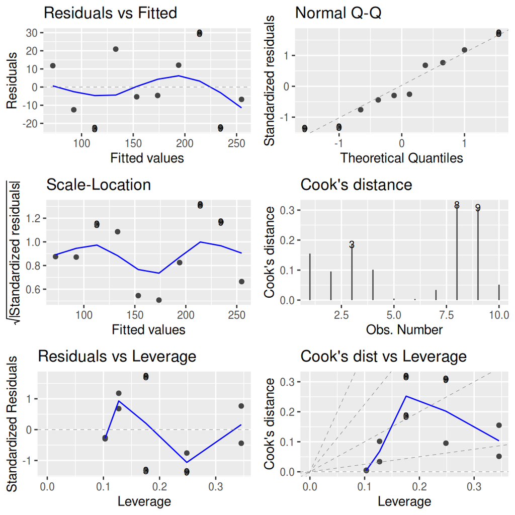

```r
fert.lm %>% autoplot(which = 1:6, ncol = 2, label.size = 3)
```

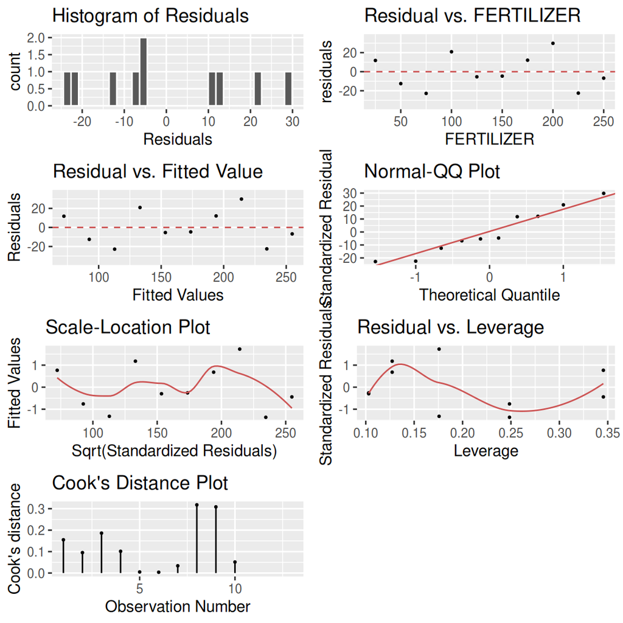

```r
fert.lm %>% lindia::gg_diagnose()
```

**Conclusions**:

- there are no alarming signs from any of the diagnostics.
- the estimated parameters are likely to be reliable.

## Influence measures

Cook’s distance (`cook.d`) and leverage (`hat`) are displayed in tabular form.

```r
fert.lm %>% influence.measures()
```

```
## Influence measures of
##   lm(formula = YIELD ~ FERTILIZER, data = fert) :
##
##       dfb.1_ dfb.FERT   dffit cov.r  cook.d   hat inf
## 1   5.39e-01  -0.4561  0.5411 1.713 0.15503 0.345
## 2  -4.15e-01   0.3277 -0.4239 1.497 0.09527 0.248
## 3  -6.01e-01   0.4237 -0.6454 0.969 0.18608 0.176
## 4   3.80e-01  -0.2145  0.4634 1.022 0.10137 0.127
## 5  -5.77e-02   0.0163 -0.0949 1.424 0.00509 0.103
## 6  -2.50e-02  -0.0141 -0.0821 1.432 0.00382 0.103
## 7  -1.80e-17   0.1159  0.2503 1.329 0.03374 0.127
## 8  -2.19e-01   0.6184  0.9419 0.623 0.31796 0.176
## 9   3.29e-01  -0.6486 -0.8390 1.022 0.30844 0.248
## 10  1.51e-01  -0.2559 -0.3035 1.900 0.05137 0.345   *
```

```r
fert.lm %>% fortify()
```

|  | YIELD | FERTILIZER | .hat | .sigma | .cooksd | .fitted | .resid | .stdresid |
| --- | --- | --- | --- | --- | --- | --- | --- | --- |
| 1 | 84 | 25 | 0.3454545 | 19.55115 | 0.155034335 | 72.21818 | 11.781818 | 0.7664845 |
| 2 | 80 | 50 | 0.2484848 | 19.56598 | 0.095267982 | 92.50303 | -12.503030 | -0.7591147 |
| 3 | 90 | 75 | 0.1757576 | 17.95943 | 0.186081798 | 112.78788 | -22.787879 | -1.3211052 |
| 4 | 154 | 100 | 0.1272727 | 18.46227 | 0.101366743 | 133.07273 | 20.927273 | 1.1790558 |
| 5 | 148 | 125 | 0.1030303 | 20.19832 | 0.005091410 | 153.35758 | -5.357576 | -0.2977422 |
| 6 | 169 | 150 | 0.1030303 | 20.22650 | 0.003822883 | 173.64242 | -4.642424 | -0.2579983 |
| 7 | 206 | 175 | 0.1272727 | 19.71511 | 0.033735022 | 193.92727 | 12.072727 | 0.6801851 |
| 8 | 244 | 200 | 0.1757576 | 16.08585 | 0.317962021 | 214.21212 | 29.787879 | 1.7269234 |
| 9 | 212 | 225 | 0.2484848 | 17.78582 | 0.308435562 | 234.49697 | -22.496970 | -1.3658913 |
| 10 | 248 | 250 | 0.3454545 | 20.06254 | 0.051368341 | 254.78182 | -6.781818 | -0.4412017 |

## Performance model checking

The `performance` package provides a similar set of visual diagnostics:

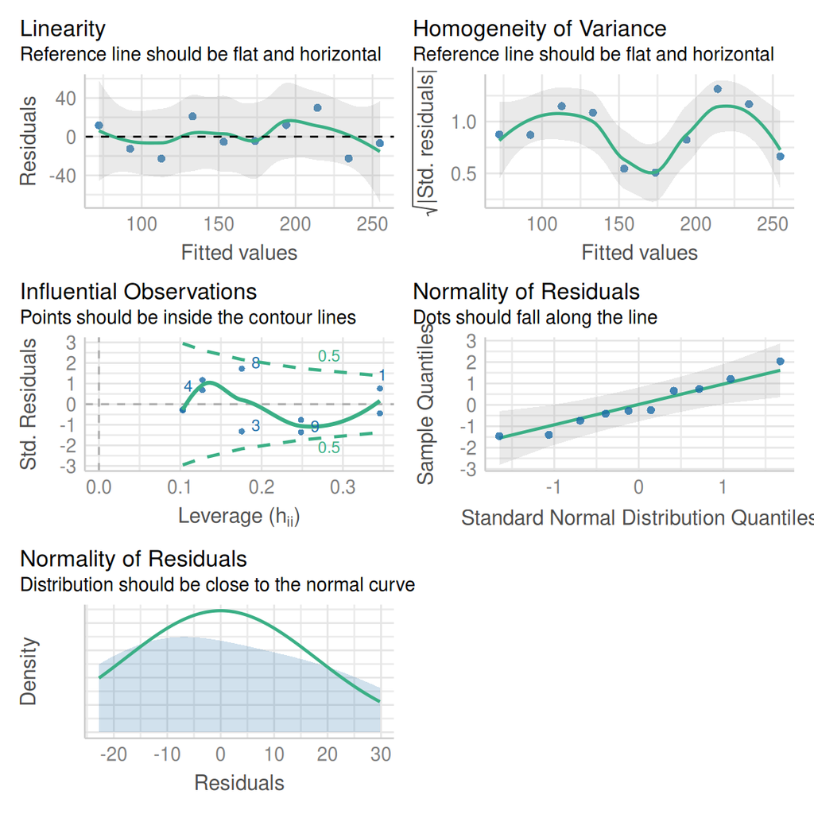

```r
fert.lm %>% performance::check_model()
```

```r
fert.lm %>% performance::check_outliers()
```

```
## OK: No outliers detected.
```

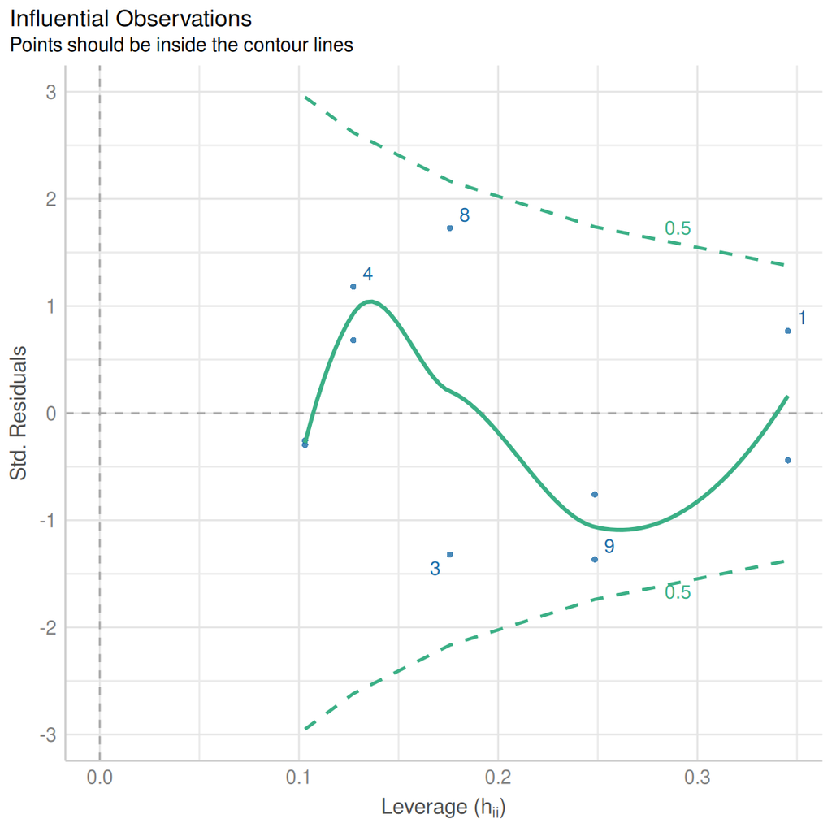

```r
fert.lm %>%
  performance::check_outliers() %>%
  plot()
```

```r
## These are probabilities of exceedance rather than actual Cook's D values
# https://easystats.github.io/performance/reference/check_outliers.html
```

**Conclusions**:

- there are no alarming signs from any of the diagnostics

## DHARMa simulated residuals

Although an exploration of model residuals can provide important insights into the goodness of fit and conformity of a model to the underlying assumptions, diagnosing issues is a bit of a fine art. This difficulty is exacerbated when the residuals are being calculated from some models (e.g logistic regression models) where it is difficult to separate out nefarious patterns from the specific patterns expected of the specific model.

The `DHARMa` package generates standardised residuals via simulation and uses these as the basis of a range of tools to diagnose common modelling issues including outliers, heterogeneity, over-dispersion, autocorrelation.

This approach ensures that all residuals have the same interpretation irrespective of the model and distribution selected.

Exploring DHARMa residuals begins with running the `simulateResiduals()` function. If this is done with `plot=TRUE`, a pair of diagnostic plots with a range of diagnostic tests will be provided as side effects.

- the left hand plot is a Q-Q plot (ideally all points should be close to the red line) the KS (Kolmogorov-Smirnov) test tests whether the (in this case simulated) are likely to have been drawn from the nominated distribution (in this case Gaussian).
- the Dispersion test tests whether the standard deviation of the data is equal to that of the simulated data
- the Outlier test tests for the prevalence of outliers (when observed values are outside the simulated range)
- the right hand plot is a residual plot. Ideally, there should be no patterns in the residuals. To help identify any patterns, quantile trends are overlayed. Ideally, there should be a flat black line at each of the quantiles of 0.25, 0.5 and 0.75.

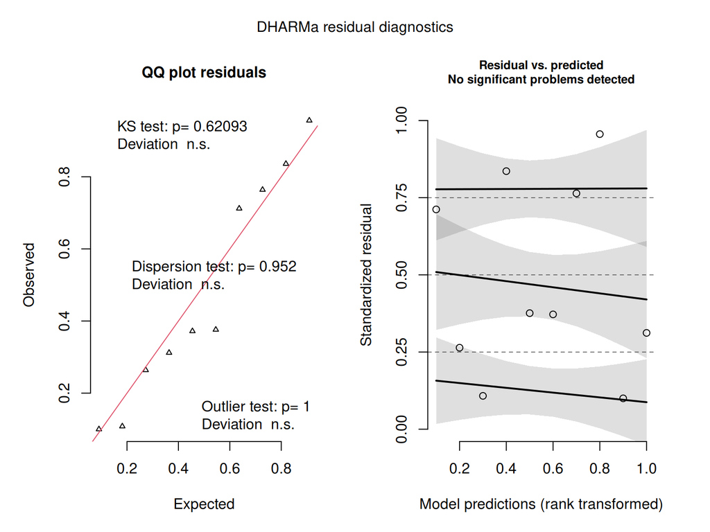

```r
fert.resid <- fert.lm %>% simulateResiduals(plot = TRUE)
```

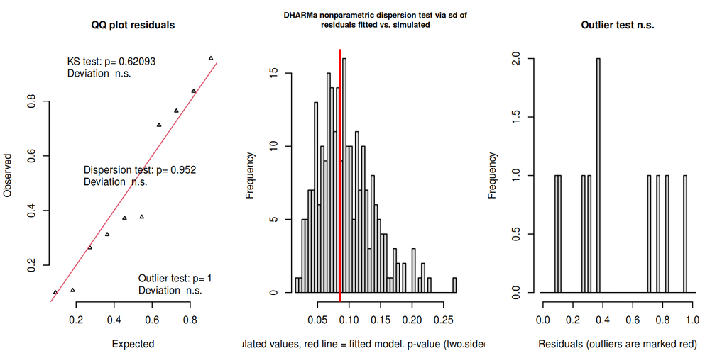

```
## $uniformity
##
##  One-sample Kolmogorov-Smirnov test
##
## data:  simulationOutput$scaledResiduals
## D = 0.224, p-value = 0.6209
## alternative hypothesis: two-sided
##
##
## $dispersion
##
##  DHARMa nonparametric dispersion test via sd of residuals fitted vs.
##  simulated
##
## data:  simulationOutput
## dispersion = 0.90609, p-value = 0.952
## alternative hypothesis: two.sided
##
##
## $outliers
##
##  DHARMa outlier test based on exact binomial test with approximate
##  expectations
##
## data:  simulationOutput
## outliers at both margin(s) = 0, observations = 10, p-value = 1
## alternative hypothesis: true probability of success is not equal to 0.007968127
## 95 percent confidence interval:
##  0.0000000 0.3084971
## sample estimates:
## frequency of outliers (expected: 0.00796812749003984 )
##                                                      0
```

[output not shown]

```r
## To run tests of KS (uniformity),  dispersion and outliers
fert.resid %>% testResiduals()
```

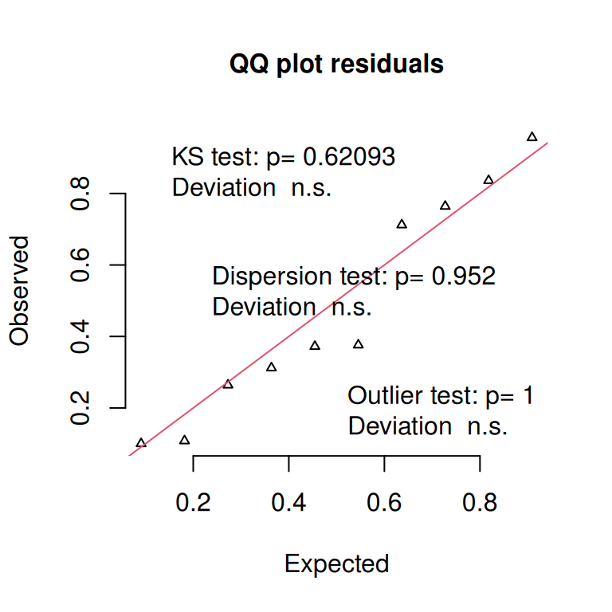

```
##
##  One-sample Kolmogorov-Smirnov test
##
## data:  simulationOutput$scaledResiduals
## D = 0.224, p-value = 0.6209
## alternative hypothesis: two-sided
```

```r
## OR individually
fert.resid %>% testUniformity()
```

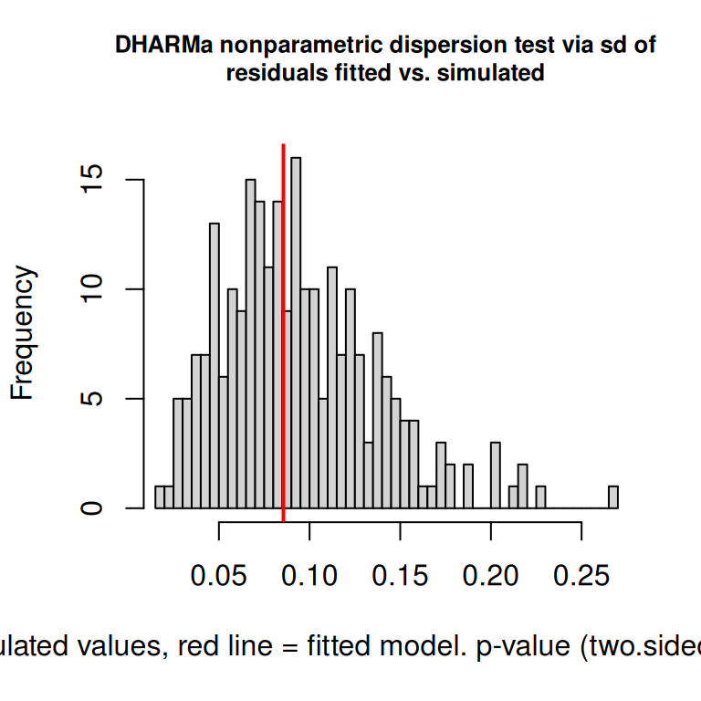

```
##
##  DHARMa nonparametric dispersion test via sd of residuals fitted vs.
##  simulated
##
## data:  simulationOutput
## dispersion = 0.90609, p-value = 0.952
## alternative hypothesis: two.sided
```

```r
fert.resid %>% testDispersion()
```

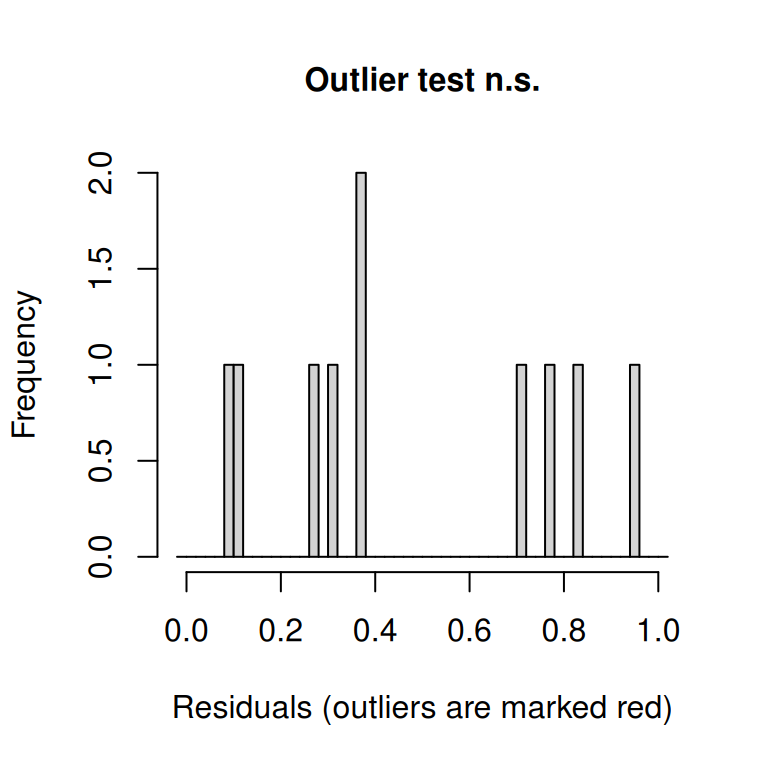

```
##
##  DHARMa outlier test based on exact binomial test with approximate
##  expectations
##
## data:  .
## outliers at both margin(s) = 0, observations = 10, p-value = 1
## alternative hypothesis: true probability of success is not equal to 0.007968127
## 95 percent confidence interval:
##  0.0000000 0.3084971
## sample estimates:
## frequency of outliers (expected: 0.00796812749003984 )
##                                                      0
```

```r
fert.resid %>% testOutliers()
```

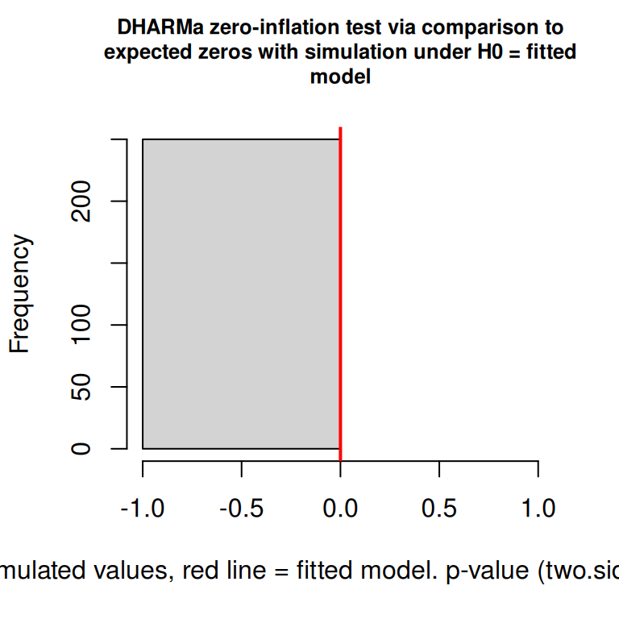

```
##
##  DHARMa zero-inflation test via comparison to expected zeros with
##  simulation under H0 = fitted model
##
## data:  simulationOutput
## ratioObsSim = NaN, p-value = 1
## alternative hypothesis: two.sided
```

```r
## Other useful tests
fert.resid %>% testZeroInflation()
```

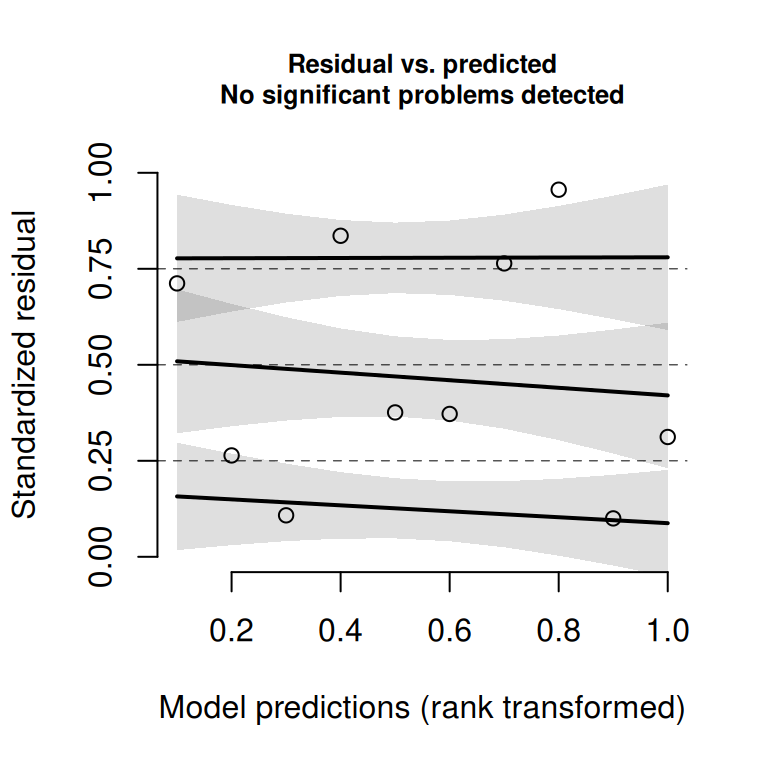

```
##
##  Test for location of quantiles via qgam
##
## data:  simulationOutput
## p-value = 0.5887
## alternative hypothesis: both
```

```r
fert.resid %>% testQuantiles()
```

```r
## The above fits quantile gams at 0.25,  0.5 and 0.75
## testSpatialAutocorrelation(fert.resid,  x=,  y=) # needs x and y coordinates
## testTemporalAutocorrelation(fert.resid,  time=) # needs time
```

## augment

The `broom` package has an `augment` method that adds information generated from a fitted model to the modelled data.

```r
fert.lm %>% augment()
```

| YIELD | FERTILIZER | .fitted | .resid | .hat | .sigma | .cooksd | .std.resid |
| --- | --- | --- | --- | --- | --- | --- | --- |
| 84 | 25 | 72.21818 | 11.781818 | 0.3454545 | 19.55115 | 0.155034335 | 0.7664845 |
| 80 | 50 | 92.50303 | -12.503030 | 0.2484848 | 19.56598 | 0.095267982 | -0.7591147 |
| 90 | 75 | 112.78788 | -22.787879 | 0.1757576 | 17.95943 | 0.186081798 | -1.3211052 |
| 154 | 100 | 133.07273 | 20.927273 | 0.1272727 | 18.46227 | 0.101366743 | 1.1790558 |
| 148 | 125 | 153.35758 | -5.357576 | 0.1030303 | 20.19832 | 0.005091410 | -0.2977422 |
| 169 | 150 | 173.64242 | -4.642424 | 0.1030303 | 20.22650 | 0.003822883 | -0.2579983 |
| 206 | 175 | 193.92727 | 12.072727 | 0.1272727 | 19.71511 | 0.033735022 | 0.6801851 |
| 244 | 200 | 214.21212 | 29.787879 | 0.1757576 | 16.08585 | 0.317962021 | 1.7269234 |
| 212 | 225 | 234.49697 | -22.496970 | 0.2484848 | 17.78582 | 0.308435562 | -1.3658913 |
| 248 | 250 | 254.78182 | -6.781818 | 0.3454545 | 20.06254 | 0.051368341 | -0.4412017 |

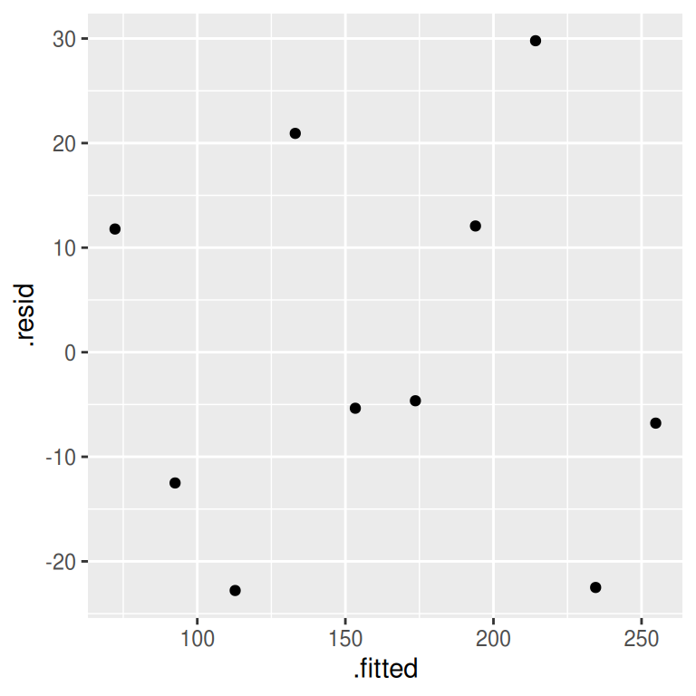

```r
## we could then pipe these to ggplot in order to look at residuals etc
fert.lm %>%
  augment() %>%
  ggplot() +
  geom_point(aes(y = .resid, x = .fitted))
```

## plot_grid

The `ssjPlot` package also has plotting methods associated with fitted models, some of which focus on model diagnostics.

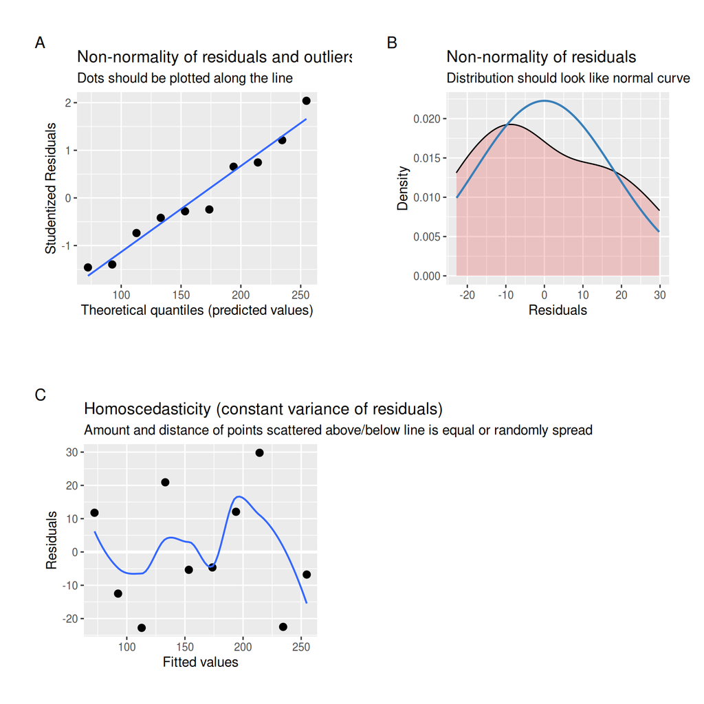

```r
fert.lm %>%
  plot_model(type = "diag") %>%
  plot_grid()
```

# Model outputs

Prior to examining the estimated coefficients and any associated hypothesis tests, it is a good idea to explore the fitted trends. Not only does this give you a sense for the overall outcomes (and help you interpret the model summaries etc), it also provides an opportunity to reflect on whether the model has yielded sensible patterns.

There are numerous ways to explore the fitted trends and these are largely based on two types of effects:

- **conditional effects**: predictions that are conditioned on certain levels (typically the reference level) of factors. For example, the trend/effects of one predictor at the first level (or first combination) of other categorical predictor(s).
- **marginal effects**: predictions that are marginalised (= averaged) over all levels of the factors. For example, the trend/effects of one predictor averaged across all levels (or combinations) of other predictors.

There are also numerous routines and packages to support these fitted trends (partial plots).

| Package | Function | Type | Notes |
| --- | --- | --- | --- |
| `sjPlot` | `plot_model(type = 'eff')` | Marginal means |  |
| `effects` | `allEffects()` | Marginal means |  |
| `ggeffects` | `ggeffects()` | Marginal means | calls `effects()` |
| `ggeffects` | `ggpredict()` | Conditional means | calls `predict()` |
| `ggeffects` | `ggemmeans()` | Marginal means | calls `emmeans()` |

Note, in the absence of categorical predictors, they will all yield the same…

## plot_model (sjPlot)

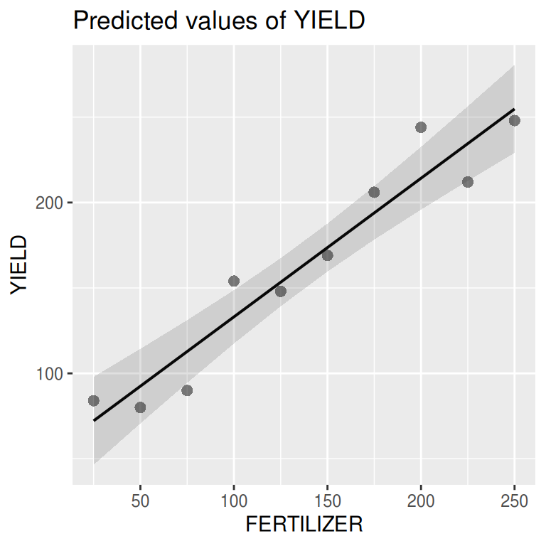

```r
fert.lm %>% plot_model(type = "eff", show.data = TRUE)
```

## allEffects (effects)

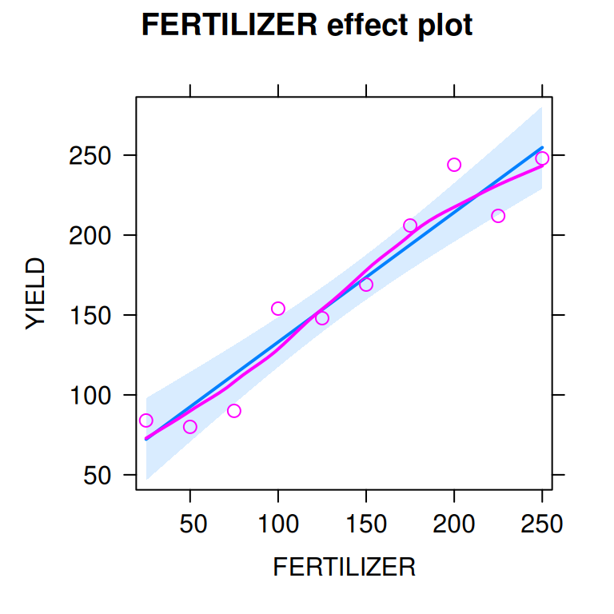

```r
plot(allEffects(fert.lm, residuals = TRUE))
```

## ggpredict (ggeffects)

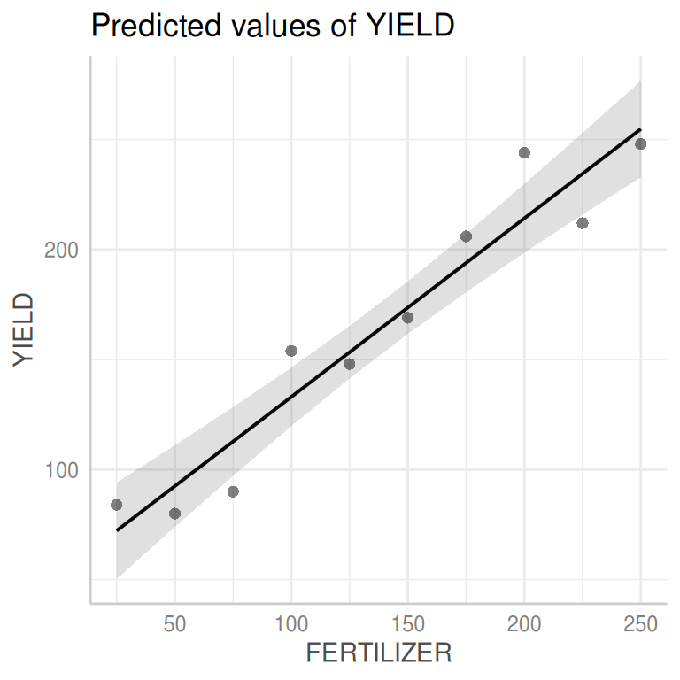

```r
fert.lm %>%
  ggpredict() %>%
  plot(add.data = TRUE, jitter = FALSE)
```

## ggemmeans (ggeffects)

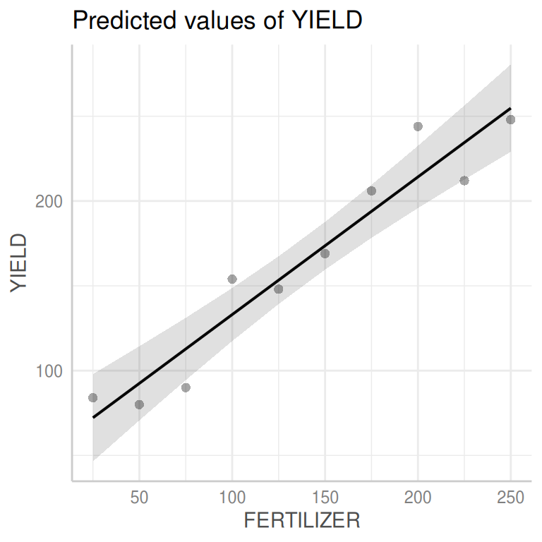

```r
fert.lm %>%
  ggemmeans(~FERTILIZER) %>%
  plot(add.data = TRUE, jitter = FALSE)
```

# Model investigation / hypothesis testing

## summary

```r
fert.lm %>% summary()
```

```
##
## Call:
## lm(formula = YIELD ~ FERTILIZER, data = fert)
##
## Residuals:
##    Min     1Q Median     3Q    Max
## -22.79 -11.07  -5.00  12.00  29.79
##
## Coefficients:
##             Estimate Std. Error t value Pr(>|t|)
## (Intercept) 51.93333   12.97904   4.001  0.00394 **
## FERTILIZER   0.81139    0.08367   9.697 1.07e-05 ***
## ---
## Signif. codes:  0 '***' 0.001 '**' 0.01 '*' 0.05 '.' 0.1 ' ' 1
##
## Residual standard error: 19 on 8 degrees of freedom
## Multiple R-squared:  0.9216, Adjusted R-squared:  0.9118
## F-statistic: 94.04 on 1 and 8 DF,  p-value: 1.067e-05
```

**Conclusions**:

- the estimated y-intercept (value of Yield when Fertiliser level is 0) is 51.93. Note, as a Fertiliser value of 0 is outside the range of the collected data, this intercept does not really have any useful interpretation (unless we are happy to extrapolate). If we had centred the Fertiliser predictor (either before modelling or as part of the model - `lm(YIELD~scale(FERTILIZER,scale=FALSE), data=fert)`), then the y-intercept would have had a sensible interpretation. It would have been the expected Yield at the average Fertiliser level. Nevertheless, either way, the hypothesis test associated with the intercept is rarely of any value.
- the estimated slope is 0.81. For every one unit increase in Fertiliser concentration, Yield is expected to increase by 0.81 units.
- the estimated slope divided by the estimated uncertainty in the slope (Std. Error) gives a t-value of 9.7. If we compare that to a t-distribution for 8, we get a p-value < 0.05. Hence we would reject the null hypothesis of no relationship between Fertiliser concentration and Yield.
- the $R^2$ value is 0.92. Hence, 92 percent of the variation in Yield is explained by its relationship to Fertiliser.

## confint

Arguably, the confidence intervals associated with each of the estimates is more useful than the p-values. P-values purely indicate the probability of detecting an effect if an effect occurs. They **do not** provide a measure of the magnitude (or importance) of the effect. The slope is the point estimate of the magnitude of the effect. Confidence intervals then provide insights into the broader range of effects. For example, in addition to describing the estimated effect size (slope), we could discuss the implications of slope with a magnitude as low as the lower confidence limit or as high as the upper confidence limit.

```r
fert.lm %>% confint()
```

```
##                  2.5 %    97.5 %
## (Intercept) 22.0036246 81.863042
## FERTILIZER   0.6184496  1.004338
```

**Conclusions**:

- we are 95% confident that an interval the size of (0.62, 1) would include the true mean slope.

## tidy

Each modelling routine (and package) may store and present its results in a different structure and format. In an attempt to unify the output, the `broom` package includes a `tidy()` method that produces more consistent outputs (structure and names) across modelling routines.

```r
fert.lm %>% tidy(conf.int = TRUE)
```

| term | estimate | std.error | statistic | p.value | conf.low | conf.high |
| --- | --- | --- | --- | --- | --- | --- |
| (Intercept) | 51.9333333 | 12.97903515 | 4.001325 | 3.942478e-03 | 22.0036246 | 81.863042 |
| FERTILIZER | 0.8113939 | 0.08367044 | 9.697499 | 1.067103e-05 | 0.6184496 | 1.004338 |

We can pipe this to `kable` if we want more formatted output.

```r
fert.lm %>%
  tidy(conf.int = TRUE) %>%
  kable()
```

| term | estimate | std.error | statistic | p.value | conf.low | conf.high |
| --- | --- | --- | --- | --- | --- | --- |
| (Intercept) | 51.9333333 | 12.9790352 | 4.001325 | 0.0039425 | 22.0036246 | 81.863042 |
| FERTILIZER | 0.8113939 | 0.0836704 | 9.697499 | 0.0000107 | 0.6184496 | 1.004338 |

## tab_model

For HTML output, the `sjPlot` package has a method for producing comparable and nicely formatted outputs across different modelling routines.

```r
# warning this is only appropriate for html output
fert.lm %>% sjPlot::tab_model(show.se = TRUE, show.aic = TRUE)
```

|  | YIELD |  |  |  |
| --- | --- | --- | --- | --- |
| Predictors | Estimates | std. Error | CI | p |
| (Intercept) | 51.93 | 12.98 | 22.00 – 81.86 | **0.004** |
| FERTILIZER | 0.81 | 0.08 | 0.62 – 1.00 | **<0.001** |
| Observations | 10 |  |  |  |
| R<sup>2</sup> / R<sup>2</sup> adjusted | 0.922 / 0.912 |  |  |  |
| AIC | 91.035 |  |  |  |

# Predictions

For simple models prediction is essentially taking the model formula complete with parameter (coefficient) estimates and solving for new values of the predictor. To explore this, we will use the fitted model to predict Yield for a Fertiliser concentration of 110.

## predict

```r
## establish a data set that defines the new data to predict against
newdata <- data.frame(FERTILIZER = 110)
## using the predict function
fert.lm %>% predict(newdata = newdata)
```

```
##        1
## 141.1867
```

```r
## include confidence intervals
fert.lm %>% predict(newdata = newdata, interval = "confidence")
```

```
##        fit      lwr      upr
## 1 141.1867 126.3506 156.0227
```

**Conclusions**:

- we expect (predict) a Yield of 141.19 associated with a Fertiliser level of 110.
- confidence intervals represent the interval in which we are 95% confident the true **Mean** value of the population falls.
- prediction intervals (not show, but described for comparison) represent the interval in which we are 95% confident a single observation drawn from the population mean will fall.

## manual calculations

```r
## establish a data set that defines the new data to predict against
newdata <- data.frame(FERTILIZER = 110)
## Establish an appropriate model matrix
Xmat <- model.matrix(~FERTILIZER, data = newdata)
## Perform matrix multiplication
(pred <- coef(fert.lm) %*% t(Xmat))
```

```
##             1
## [1,] 141.1867
```

```r
## Calculate the standard error
se <- sqrt(diag(Xmat %*% vcov(fert.lm) %*% t(Xmat)))
## Calculate the confidence intervals
as.numeric(pred) + outer(se, qt(df = df.residual(fert.lm), c(0.025, 0.975)))
```

```
##       [,1]     [,2]
## 1 126.3506 156.0227
```

## emmeans

The `emmeans` package has a set of routines for estimating marginal means from fitted models.

```r
## using emmeans
newdata <- list(FERTILIZER = 110)
fert.lm %>% emmeans(~FERTILIZER, at = newdata)
```

```
##  FERTILIZER emmean   SE df lower.CL upper.CL
##         110    141 6.43  8      126      156
##
## Confidence level used: 0.95
```

Note, the above outputs are rounded only for the purpose of constructing the printed table on screen. If we were to capture the output of the `emmeans()` function, the values would not be rounded.

# Additional analyses

Having fitted the simple linear model, we can further interrogate the model to explore additional facets.

## glht

```r
## testing a specific hypothesis
## Probabiliy of getting our estimate if slope was 1
fert.lm %>%
  multcomp::glht(linfct = c("FERTILIZER == 1")) %>%
  summary()
```

```
##
##   Simultaneous Tests for General Linear Hypotheses
##
## Fit: lm(formula = YIELD ~ FERTILIZER, data = fert)
##
## Linear Hypotheses:
##                 Estimate Std. Error t value Pr(>|t|)
## FERTILIZER == 1  0.81139    0.08367  -2.254   0.0542 .
## ---
## Signif. codes:  0 '***' 0.001 '**' 0.01 '*' 0.05 '.' 0.1 ' ' 1
## (Adjusted p values reported -- single-step method)
```

```r
## Cant ask probability that the slope is equal to something in frequentist
## If we wanted to know the probability that the slope was greater than
## 1, the closest we could get is
fert.lm %>%
  multcomp::glht(linfct = c("FERTILIZER >= 0.9")) %>%
  summary()
```

```
##
##   Simultaneous Tests for General Linear Hypotheses
##
## Fit: lm(formula = YIELD ~ FERTILIZER, data = fert)
##
## Linear Hypotheses:
##                   Estimate Std. Error t value Pr(<t)
## FERTILIZER >= 0.9  0.81139    0.08367  -1.059   0.16
## (Adjusted p values reported -- single-step method)
```

## hypothesis

```r
## testing a specific hypothesis
## Probabiliy of getting our estimate if slope was 1
fert.lm %>% brms::hypothesis("FERTILIZER = 1")
```

```
## Hypothesis Tests for class :
##             Hypothesis Estimate Est.Error CI.Lower CI.Upper Evid.Ratio
## 1 (FERTILIZER)-(1) = 0    -0.18      0.09    -0.33     0.02         NA
##   Post.Prob Star
## 1        NA
## ---
## 'CI': 90%-CI for one-sided and 95%-CI for two-sided hypotheses.
## '*': For one-sided hypotheses, the posterior probability exceeds 95%;
## for two-sided hypotheses, the value tested against lies outside the 95%-CI.
## Posterior probabilities of point hypotheses assume equal prior probabilities.
```

```r
## Cant ask probability that the slope is equal to something in frequentist
## If we wanted to know the probability that the slope was greater than
## 1, the closest we could get is
fert.lm %>% brms::hypothesis("FERTILIZER > 0.9")
```

```
## Hypothesis Tests for class :
##               Hypothesis Estimate Est.Error CI.Lower CI.Upper Evid.Ratio
## 1 (FERTILIZER)-(0.9) > 0    -0.08      0.09     -0.2     0.07       0.18
##   Post.Prob Star
## 1      0.15
## ---
## 'CI': 90%-CI for one-sided and 95%-CI for two-sided hypotheses.
## '*': For one-sided hypotheses, the posterior probability exceeds 95%;
## for two-sided hypotheses, the value tested against lies outside the 95%-CI.
## Posterior probabilities of point hypotheses assume equal prior probabilities.
```

## emmeans

We could explore the expected change in Yield associated with a specific increase in Fertiliser. For example, how much do we expect Yield to increase when increasing Fertiliser concentration from 100 to 200.

```r
newdata <- list(FERTILIZER = c(200, 100))
fert.lm %>% emmeans(~FERTILIZER, at = newdata)
```

```
##  FERTILIZER emmean   SE df lower.CL upper.CL
##         200    214 7.97  8      196      233
##         100    133 6.78  8      117      149
##
## Confidence level used: 0.95
```

```r
fert.lm %>%
  emmeans(~FERTILIZER, at = newdata) %>%
  pairs()
```

```
##  contrast  estimate   SE df t.ratio p.value
##  200 - 100     81.1 8.37  8   9.697  <.0001
```

```r
fert.lm %>%
  emmeans(~FERTILIZER, at = newdata) %>%
  pairs() %>%
  confint()
```

|  | contrast | estimate | SE | df | lower.CL | upper.CL |
| --- | --- | --- | --- | --- | --- | --- |
| 1 | 200 - 100 | 81.13939 | 8.367044 | 8 | 61.84496 | 100.4338 |

```r
fert.lm %>%
  emmeans(~FERTILIZER, at = newdata) %>%
  pairs() %>%
  summary(infer = TRUE)
```

|  | contrast | estimate | SE | df | lower.CL | upper.CL | t.ratio | p.value |
| --- | --- | --- | --- | --- | --- | --- | --- | --- |
| 1 | 200 - 100 | 81.13939 | 8.367044 | 8 | 61.84496 | 100.4338 | 9.697499 | 1.06752e-05 |

```r
fert.lm %>% emmeans(pairwise ~ FERTILIZER, at = newdata)
```

```
## $emmeans
##  FERTILIZER emmean   SE df lower.CL upper.CL
##         200    214 7.97  8      196      233
##         100    133 6.78  8      117      149
##
## Confidence level used: 0.95
##
## $contrasts
##  contrast  estimate   SE df t.ratio p.value
##  200 - 100     81.1 8.37  8   9.697  <.0001
```

```r
## or with confidence intervals
fert.lm %>%
  emmeans(pairwise ~ FERTILIZER, at = newdata) %>%
  confint()
```

```
## $emmeans
##  FERTILIZER emmean   SE df lower.CL upper.CL
##         200    214 7.97  8      196      233
##         100    133 6.78  8      117      149
##
## Confidence level used: 0.95
##
## $contrasts
##  contrast  estimate   SE df lower.CL upper.CL
##  200 - 100     81.1 8.37  8     61.8      100
##
## Confidence level used: 0.95
```

```r
## What if we wanted to calculate the percentage increase in yield associated with this change
## Lets consider what a percentage change is:
## If a value changed from 15 to 20, what percentage change is this?
## 20/15 = 1.333 therefore, a 33.3% increase
## But when working with model parameters, can only work with + -, not * and /
## To do this in a frequentist model, we need to use a log law trick
## log(A-B) = log(A)/log(B)
## So what we need to do is:
## - take out cell means
## - log them
## - subtract them
## - them back-transform (exp)
fert.lm %>%
  emmeans(~FERTILIZER, at = newdata) %>%
  regrid(transform = "log") %>%
  pairs() %>%
  summary(infer = TRUE) %>%
  mutate(across(c(estimate, lower.CL, upper.CL), exp)) %>%
  as.data.frame()
```

|  | contrast | estimate | SE | df | lower.CL | upper.CL | t.ratio | p.value |
| --- | --- | --- | --- | --- | --- | --- | --- | --- |
| 1 | 200 - 100 | 1.609737 | 0.05094673 | 8 | 1.431306 | 1.810412 | 9.344485 | 1.405195e-05 |

```r
## And if we wanted to express it as a decline from FERTILIZER 200 to 100
fert.lm %>%
  emmeans(~FERTILIZER, at = newdata) %>%
  regrid(transform = "log") %>%
  pairs(reverse = TRUE) %>%
  summary(infer = TRUE) %>%
  mutate(across(c(estimate, lower.CL, upper.CL), exp)) %>%
  as.data.frame()
```

|  | contrast | estimate | SE | df | lower.CL | upper.CL | t.ratio | p.value |
| --- | --- | --- | --- | --- | --- | --- | --- | --- |
| 1 | 100 - 200 | 0.6212194 | 0.05094673 | 8 | 0.5523605 | 0.6986624 | -9.344485 | 1.405195e-05 |

# Summary figures

Although there are numerous easy to use routines that will generate partial plots (see above), it is also useful to be able to produce the data behind the figures yourself. That way, you can have more control over the type and style of the figures.

Producing a summary figure is essentially plotting the results of predictions. In the case of a trend, we want a series of predictions associated with a sequence of predictor values. Hence, we establish a prediction grid that contains the sequence of values for the predictor we would like to display.

There are a number of functions we can use to generate different sequences of prediction values. For example, we may want a sequence of values from the lowest to the highest observed predictor value. Alternatively, we may just want to explore predictions at the first, third and fifth quantiles. The following table indicates some of the functions that are helpful for these purposes.

| Function | Values returned |
| --- | --- |
| `modelr::seq_range()` | equal increment values from smallest to largest |
| `Hmisc::smean_sdl()` | mean as well as mean plus/minus one standard deviation |
| `Hmisc::smedian_hilow()` | median as well as min and max |
| `Hmisc::smean.cl.normal()` | mean as well as lower and upper 95% confidence interval |

## emmeans

```r
## Using emmeans
fert_grid <- with(fert, list(FERTILIZER = seq_range(FERTILIZER, n = 100)))
## OR
fert_grid <- fert %>% data_grid(FERTILIZER = seq_range(FERTILIZER, n = 100))
newdata <- fert.lm %>%
  emmeans(~FERTILIZER, at = fert_grid) %>%
  as.data.frame()
newdata <- fert.lm %>%
  emmeans(~FERTILIZER, at = fert_grid) %>%
  as.data.frame()
newdata %>% head()
```

|  | FERTILIZER | emmean | SE | df | lower.CL | upper.CL |
| --- | --- | --- | --- | --- | --- | --- |
| 1 | 25.00000 | 72.21818 | 11.16695 | 8 | 46.46715 | 97.96921 |
| 2 | 27.27273 | 74.06226 | 11.00713 | 8 | 48.67977 | 99.44475 |
| 3 | 29.54545 | 75.90634 | 10.84830 | 8 | 50.89012 | 100.92255 |
| 4 | 31.81818 | 77.75041 | 10.69048 | 8 | 53.09812 | 102.40271 |
| 5 | 34.09091 | 79.59449 | 10.53374 | 8 | 55.30365 | 103.88533 |
| 6 | 36.36364 | 81.43857 | 10.37811 | 8 | 57.50661 | 105.37053 |

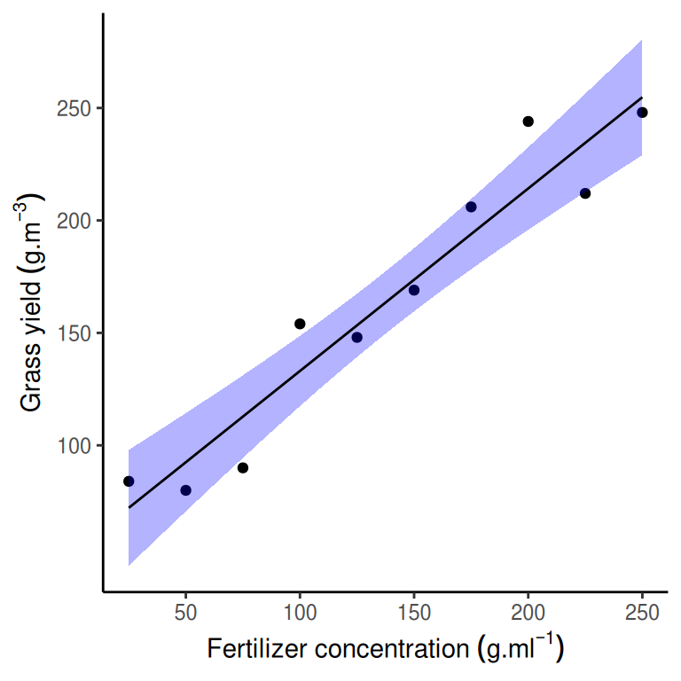

```r
ggplot(newdata, aes(y = emmean, x = FERTILIZER)) +
  geom_point(data = fert, aes(y = YIELD)) +
  geom_ribbon(aes(ymin = lower.CL, ymax = upper.CL), fill = "blue", alpha = 0.3) +
  geom_line() +
  scale_y_continuous(expression(Grass ~ yield ~ (g.m^-3)), breaks = c(100, 150, 200, 250)) +
  scale_x_continuous(expression(Fertilizer ~ concentration ~ (g.ml^-1))) +
  theme_classic()
```

## emmeans with partial residuals

For more complex models that include additional covariates, the partial plot represents the expected trend between the response and focal predictor holding all other predictors constant. This is akin to plotting the trend between the response and focal predictor after standardising first for the other covariate(s).

When this is the case, it is not always appropriate to overlay a partial plot with raw data (as this data has not been standardised and will not necessarily represent the partial effects). Arguably a more appropriate way to represent the data points, is to calculate standardised version of the points by adding the residuals onto the fitted values associated with each of the observed values of the focal predictor. When there is only a single predictor, as is the case here, the result will be identical to just overlaying the raw data.

We can either do this by leveraging completely off the `ggemmeans()` function (or `ggpredict()` if we want conditional predictions).

```r
## Using emmeans
fert_grid <- fert %>% data_grid(FERTILIZER = seq_range(FERTILIZER, n = 100))
newdata <- fert.lm %>%
  emmeans(~FERTILIZER, at = fert_grid) %>%
  as.data.frame()
newdata <- fert.lm %>%
  emmeans(~FERTILIZER, at = fert_grid) %>%
  as.data.frame()
newdata %>% head()
```

|  | FERTILIZER | emmean | SE | df | lower.CL | upper.CL |
| --- | --- | --- | --- | --- | --- | --- |
| 1 | 25.00000 | 72.21818 | 11.16695 | 8 | 46.46715 | 97.96921 |
| 2 | 27.27273 | 74.06226 | 11.00713 | 8 | 48.67977 | 99.44475 |
| 3 | 29.54545 | 75.90634 | 10.84830 | 8 | 50.89012 | 100.92255 |
| 4 | 31.81818 | 77.75041 | 10.69048 | 8 | 53.09812 | 102.40271 |
| 5 | 34.09091 | 79.59449 | 10.53374 | 8 | 55.30365 | 103.88533 |
| 6 | 36.36364 | 81.43857 | 10.37811 | 8 | 57.50661 | 105.37053 |

```r
## Now generate partial residuals
fitted_grid <- fert
fit <- fert.lm %>%
  emmeans(~FERTILIZER, at = fitted_grid) %>%
  as.data.frame() %>%
  pull(emmean)
resid.newdata <- fert %>%
  mutate(
    Fit = fit,
    Resid = resid(fert.lm),
    Partial.obs = Fit + Resid
  )
resid.newdata %>% head()
```

| FERTILIZER | YIELD | Fit | Resid | Partial.obs |
| --- | --- | --- | --- | --- |
| 25 | 84 | 72.21818 | 11.781818 | 84 |
| 50 | 80 | 92.50303 | -12.503030 | 80 |
| 75 | 90 | 112.78788 | -22.787879 | 90 |
| 100 | 154 | 133.07273 | 20.927273 | 154 |
| 125 | 148 | 153.35758 | -5.357576 | 148 |
| 150 | 169 | 173.64242 | -4.642424 | 169 |

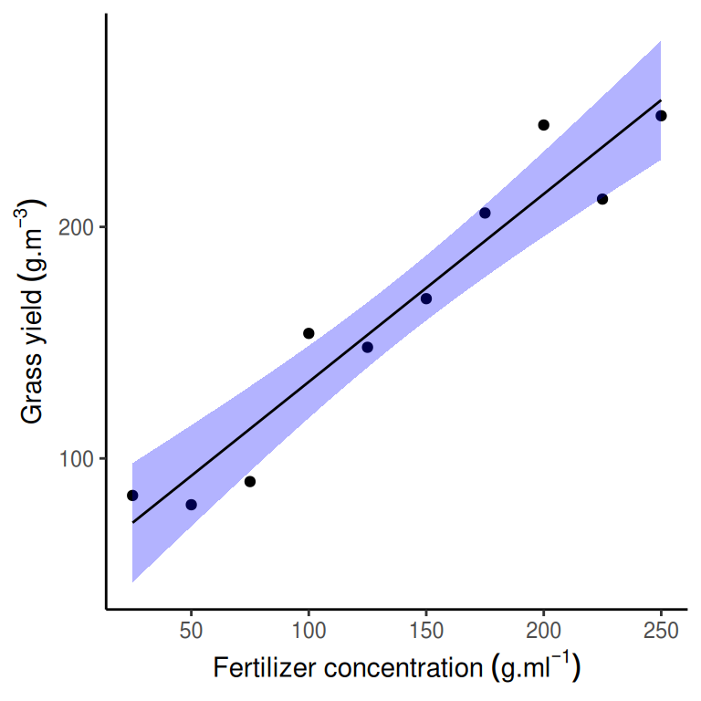

```r
ggplot(newdata, aes(y = emmean, x = FERTILIZER)) +
  geom_point(data = resid.newdata, aes(y = Partial.obs)) +
  geom_ribbon(aes(ymin = lower.CL, ymax = upper.CL), fill = "blue", alpha = 0.3) +
  geom_line() +
  scale_y_continuous(expression(Grass ~ yield ~ (g.m^-3))) +
  scale_x_continuous(expression(Fertilizer ~ concentration ~ (g.ml^-1))) +
  theme_classic()
```

## manually

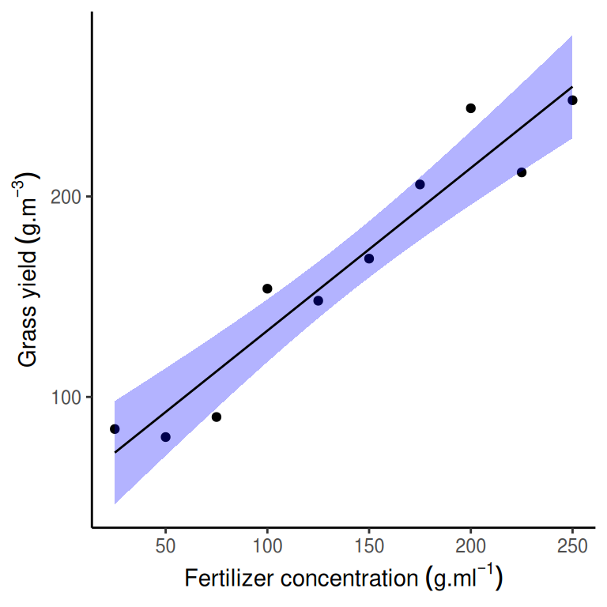

```r
## Using emmeans
newdata <- with(fert, data.frame(FERTILIZER = seq(min(FERTILIZER), max(FERTILIZER), len = 100)))
Xmat <- model.matrix(~FERTILIZER, data = newdata)
coefs <- coef(fert.lm)
preds <- coefs %*% t(Xmat)
se <- sqrt(diag(Xmat %*% vcov(fert.lm) %*% t(Xmat)))
fert.df <- df.residual(fert.lm)
newdata <- newdata %>%
  mutate(
    fit = as.vector(preds),
    lower = fit - qt(0.975, df = fert.df) * se,
    upper = fit + qt(0.975, df = fert.df) * se
  )
ggplot(newdata, aes(y = fit, x = FERTILIZER)) +
  geom_point(data = fert, aes(y = YIELD)) +
  geom_ribbon(aes(ymin = lower, ymax = upper), fill = "blue", alpha = 0.3) +
  geom_line() +
  scale_y_continuous(expression(Grass ~ yield ~ (g.m^-3))) +
  scale_x_continuous(expression(Fertilizer ~ concentration ~ (g.ml^-1))) +
  theme_classic()
```

# Methods

- The relationship between grass yield and fertiliser concentration was explored using linear regression.
- The model was validated via DHARMa (cite) residuals
- All models and graphics were conducted within the R (4.1.0) statistical and graphical environment (cite).

# Results

# References

Fowler, J., L. Cohen, and P. Jarvis. 1998. *Practical Statistics for Field Biology*. England: John Wiley & Sons.